# 重定义地点后分析报告

Kang

## 引言

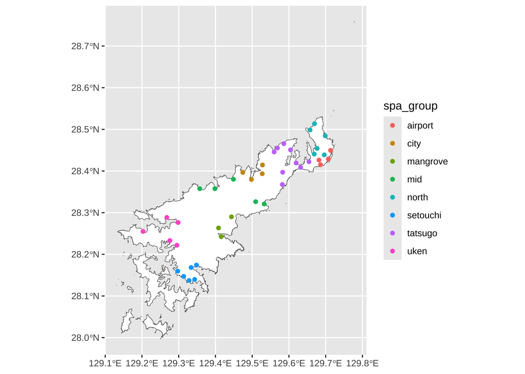

```r
ggplot() +
  geom_sf(data = amami, fill = "white") +
  geom_sf(data = st_centroid(loc), aes(col = spa_group))
```

各个组团包含的节点数量如下。

```r
table(loc$spa_group)
```

```
##
##  airport     city mangrove      mid    north setouchi  tatsugo     uken
##        4        4        3        5        6        6        9        5
```

## 对比组团节点网络指标

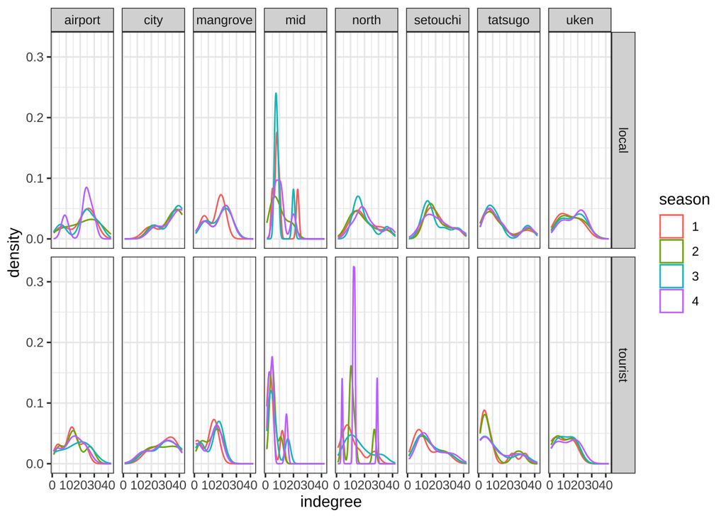

```r
combined_data %>%
  left_join(st_drop_geometry(loc), by = c("id" = "loc_id")) %>%
  ggplot() +
  geom_density(aes(indegree, group = season, col = as.character(season))) +
  facet_grid(vis_src ~ spa_group) +
  theme_bw() +
  labs(col = "season")
```

由于同时进行多个维度对比比较困难，所以我们也可以考虑忽略一个维度，如季节。那么就可以用箱形图加统计对比。从下图可以看出，不管对于本地人还是游客，组团之间的indegree的趋势是类似的，例如city比较高，mid比较低。

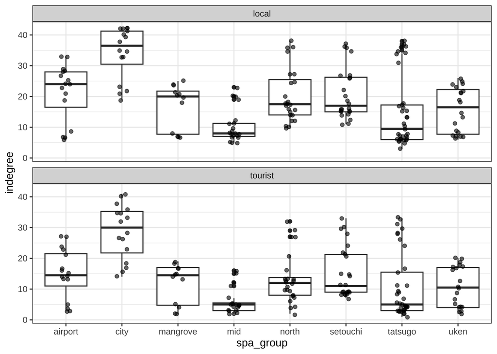

```r
combined_data %>%
  left_join(st_drop_geometry(loc), by = c("id" = "loc_id")) %>%
  ggplot(aes(spa_group, indegree)) +
  geom_boxplot() +
  geom_jitter(alpha = 0.6, width = 0.1) +
  facet_wrap(.~ vis_src, ncol = 1) +
  theme_bw() +
  labs(col = "season")
```

类似地，可以对其他网络指标进行可视化。可见城市组团的节点各个网络指标都比较高。

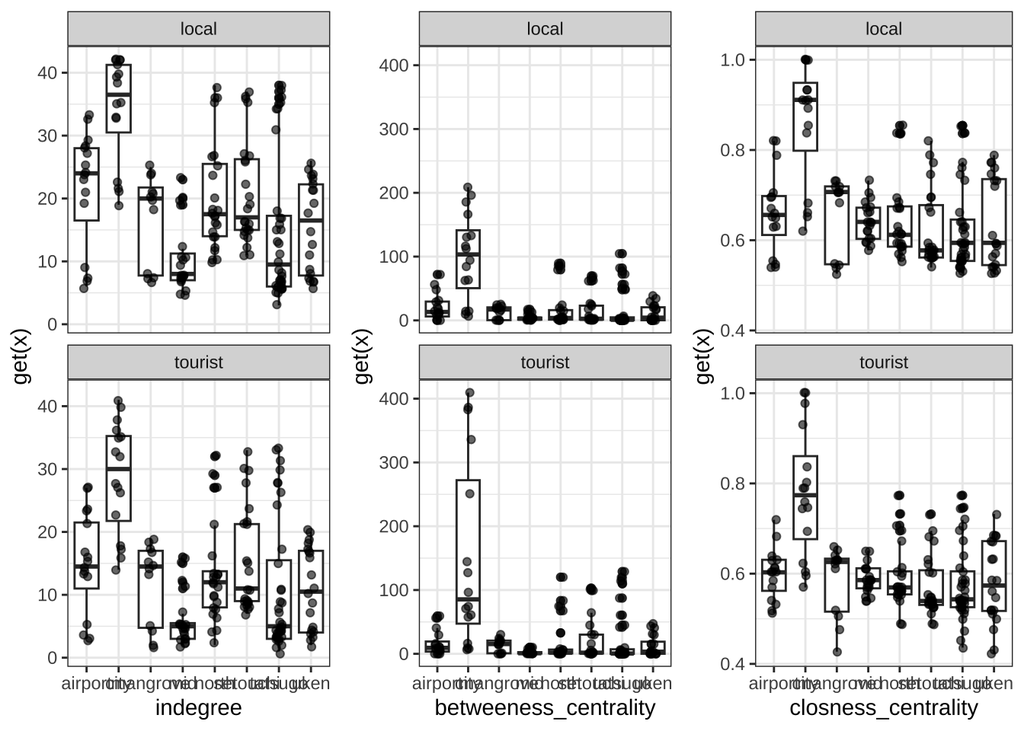

```r
lapply(
  c("indegree", "betweeness_centrality", "closness_centrality"),
  function(x) {
    combined_data %>%
  left_join(st_drop_geometry(loc), by = c("id" = "loc_id")) %>%
  ggplot(aes(spa_group, get(x))) +
  geom_boxplot() +
  geom_jitter(alpha = 0.6, width = 0.1) +
  facet_wrap(.~ vis_src, ncol = 1) +
  theme_bw() +
  labs(col = "season", x = x)
  }
) %>%
  cowplot::plot_grid(plotlist = ., nrow = 1)
```

## 连接供需

基于之前的讨论，对各个节点的基础设施供需进行对比，以提供基础设施建设或服务投资的建议。主要思路是：以节点的网络指标表示需求，因为需求跟人类行为有关；对应的服务或基础设施POI密度作为供给；对比节点的需求和供给，以标准化后的两者比率表示供给率。

各网络指标和服务之间的匹配如下：

- 对本地人：indegree高 - 作为目的地的吸引力强 - 对应本地服务，如市政中心；
- 对游客：indegree高 - 作为旅游目的地的吸引力强 - 对应应增加旅游基础设施如酒店、餐厅、景点；Betweenness高 - 从此处中转的人多 - 可作为交通枢纽；Closeness高 - 到其他点的“平均距离”小 - 可能是中心景点或具有中心景点潜力。

可分析不同客源不同季节下，各类别基础设施或服务的供给率。由于目前我没有POI的资料（需要讨论，讨论后请把各点一定缓冲区内的POI数据发给我哈），因此智能做一下需求量的可视化。举个例子：indegree的大小。

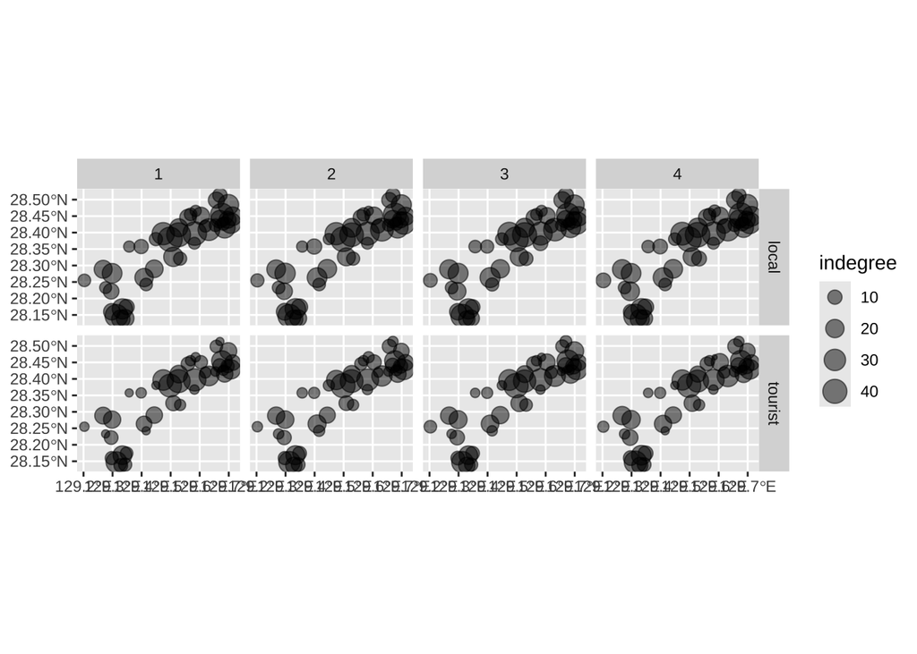

```r
loc %>%
  st_centroid() %>%
  left_join(combined_data, by = c("loc_id" = "id")) %>%
  ggplot() +
  geom_sf(aes(size = indegree), alpha = 0.5) +
  facet_grid(vis_src ~ season)
```

我们可以继续：做另外两个网络指标的可视化。

还可以：根据不同指标的大小进行可视化，例如绿色表示indegree大的点，红色表示betweenness大的点，蓝色表示closeness大的点等等。